# Musterloesung Aufgabe 3.1 Multiple Regression

Statistik3

Statistik

- R-Skript als Download
- Lösungstext als Download

## Übungsaufgabe (hier so ausführlich formuliert, wie dies auch in der Klausur der Fall sein wird)

- Bereiten Sie den Datensatz Ukraine.xlsx für das Einlesen in R vor und lesen Sie ihn dann ein. Dieser enthält gemittelte Pflanzenartenzahlen (Species.richness) von 199 10 m² grossen Plots (Vegetationsaufnahmen) von Steppenrasen in der Ukraine sowie zahlreiche Umweltvariablen, deren Bedeutung und Einheiten im Kopf der ExcelTabelle angegeben sind.
- **Ermitteln Sie ein minimal adäquates Modell, das den Artenreichtum in den Plots durch die Umweltvariablen erklärt.**
- Bitte erklären und begründen Sie die einzelnen Schritte, die Sie unternehmen, um zu diesem Ergebnis zu kommen. Dazu erstellen Sie bitte ein Word-Dokument, in das Sie Schritt für Schritt den verwendeten R-Code, die dazu gehörigen Ausgaben von R, Ihre Interpretation derselben und die sich ergebenden Schlussfolgerungen für das weitere Vorgehen dokumentieren.
- Dieser Ablauf sollte insbesondere beinhalten:
  - Überprüfen der Datenstruktur nach dem Einlesen: welches sind die abhängige(n) und welches die unabängige(n) Variablen, sind alle Variablen für die Analyse geeignet?
  - Explorative Datenanalyse, um zu sehen, ob die abhängige Variable in der vorliegenden Form für die Analyse geeignet ist
  - Definition eines globalen Modelles und dessen Reduktion zu einem minimal adäquaten Modell
  - Durchführen der Modelldiagnostik für dieses
  - Generieren aller Zahlen, Statistiken und Tabellen, die für eine wiss. Ergebnisdarstellung benötigt werden
  - Formulieren Sie abschliessend einen Methoden- und Ergebnisteil (ggf. incl. adäquaten Abbildungen) zu dieser Untersuchung in der Form einer wissenschaftlichen Arbeit (ausformulierte schriftliche Zusammenfassung, mit je einem Absatz von ca. 60-100 Worten, resp. 3-8 Sätzen für den Methoden- und Ergebnisteil). D. h. alle wichtigen Informationen sollten enthalten sein, unnötige Redundanz dagegen vermieden werden.
  - **Abzugeben sind am Ende (a) Ein lauffähiges R-Skript; (b) begründeter Lösungsweg (Kombination aus R-Code, R Output und dessen Interpretation) und (c) ausformulierter Methoden- und Ergebnisteil (für eine wiss. Arbeit).**

## Loesung Übung 3.1: Multiple Regression

Schon vor dem Einlesen kürzt man am besten bereits in Excel die Variablennamen so ab, dass sie noch eindeutig, aber nicht unnötig lang sind, etwa indem man die Einheiten wegstreicht

```r
library(readr)
# Aus der Excel-Tabelle wurde das relevante Arbeitsblatt als csv gespeichert
ukraine <-read_delim("Ukraine_bearbeitet.csv", delim=";")
attach(ukraine)

ukraine
```

```
# A tibble: 199 × 23
   `Plot ID` `Species richness` Altitude Inclination `Heat index`
   <chr>                  <dbl>    <dbl>       <dbl>        <dbl>
 1 UA01NW                    44      179          24        -0.42
 2 UA01SE                    53      178          17        -0.3
 3 UA02NW                    48      188          27        -0.51
 4 UA02SE                    50      183          33        -0.65
 5 UA03NW                    53      162           7        -0.09
 6 UA03SE                    40      165          33        -0.42
 7 UA04NW                    46      153          30         0
 8 UA04SE                    56      158          32        -0.59
 9 UA05NW                    30      192          25         0.46
10 UA05SE                    35      197          18         0.32
# … with 189 more rows, and 18 more variables: Microrelief <dbl>,
#   Grazing intensity <dbl>, Litter <dbl>, Stones and rocks <dbl>,
#   Gravel <dbl>, Fine soil <dbl>, Sand <dbl>, Silt <dbl>,
#   Clay <dbl>, pH <dbl>, Conductivity <dbl>, CaCO3 <dbl>,
#   N total <dbl>, C org <dbl>, CN ratio <dbl>, Temperature <dbl>,
#   Temperature range <dbl>, Precipitation <dbl>
```

```r
# ukraine <- read.delim("Ukraine_bearbeitet.csv",sep=";")

str(ukraine)
```

```
spec_tbl_df [199 × 23] (S3: spec_tbl_df/tbl_df/tbl/data.frame)
 $ Plot ID          : chr [1:199] "UA01NW" "UA01SE" "UA02NW" "UA02SE" ...
 $ Species richness : num [1:199] 44 53 48 50 53 40 46 56 30 35 ...
 $ Altitude         : num [1:199] 179 178 188 183 162 165 153 158 192 197 ...
 $ Inclination      : num [1:199] 24 17 27 33 7 33 30 32 25 18 ...
 $ Heat index       : num [1:199] -0.42 -0.3 -0.51 -0.65 -0.09 -0.42 0 -0.59 0.46 0.32 ...
 $ Microrelief      : num [1:199] 5 2.5 2 2 3 4 16 15 5 3 ...
 $ Grazing intensity: num [1:199] 0 0 0 0 0 0 1 1 0 0 ...
 $ Litter           : num [1:199] 12 10 0 4 15 30 5 6 10 20 ...
 $ Stones and rocks : num [1:199] 0 0 0 0 0 0 40 10 0 0 ...
 $ Gravel           : num [1:199] 0 0 0 0 0 0 0 0 0 0 ...
 $ Fine soil        : num [1:199] 2 5 0 7 0 0 2 5 5 2 ...
 $ Sand             : num [1:199] 45 30 20 20 55 30 10 30 10 5 ...
 $ Silt             : num [1:199] 40 35 60 60 10 35 60 35 60 90 ...
 $ Clay             : num [1:199] 15 35 20 20 35 35 30 35 30 5 ...
 $ pH               : num [1:199] 7.32 6.91 6.72 6.44 6.1 6.23 6.79 6.43 7.19 7 ...
 $ Conductivity     : num [1:199] 90 115 126 90 73 76 163 119 151 69 ...
 $ CaCO3            : num [1:199] 0.0754 0.1271 0.0723 0.0771 0.0829 ...
 $ N total          : num [1:199] 0.14 0.17 0.24 0.26 0.29 0.2 0.34 0.29 0.18 0.2 ...
 $ C org            : num [1:199] 1.54 1.97 2.99 3.22 3.77 2.5 4.59 3.67 2.16 2.38 ...
 $ CN ratio         : num [1:199] 10.8 11.5 12.5 12.6 12.8 ...
 $ Temperature      : num [1:199] 79 79 80 80 82 82 82 82 79 83 ...
 $ Temperature range: num [1:199] 330 330 329 329 328 328 328 328 326 327 ...
 $ Precipitation    : num [1:199] 608 608 603 603 594 594 594 594 600 586 ...
 - attr(*, "spec")=
  .. cols(
  ..   `Plot ID` = col_character(),
  ..   `Species richness` = col_double(),
  ..   Altitude = col_double(),
  ..   Inclination = col_double(),
  ..   `Heat index` = col_double(),
  ..   Microrelief = col_double(),
  ..   `Grazing intensity` = col_double(),
  ..   Litter = col_double(),
  ..   `Stones and rocks` = col_double(),
  ..   Gravel = col_double(),
  ..   `Fine soil` = col_double(),
  ..   Sand = col_double(),
  ..   Silt = col_double(),
  ..   Clay = col_double(),
  ..   pH = col_double(),
  ..   Conductivity = col_double(),
  ..   CaCO3 = col_double(),
  ..   `N total` = col_double(),
  ..   `C org` = col_double(),
  ..   `CN ratio` = col_double(),
  ..   Temperature = col_double(),
  ..   `Temperature range` = col_double(),
  ..   Precipitation = col_double()
  .. )
 - attr(*, "problems")=<externalptr>
```

```r
summary(ukraine)
```

```
   Plot ID          Species richness    Altitude      Inclination
 Length:199         Min.   :14.00    Min.   : 73.0   Min.   : 1.00
 Class :character   1st Qu.:34.00    1st Qu.:140.0   1st Qu.:12.00
 Mode  :character   Median :40.00    Median :166.0   Median :19.00
                    Mean   :40.23    Mean   :161.7   Mean   :19.28
                    3rd Qu.:47.50    3rd Qu.:188.0   3rd Qu.:25.00
                    Max.   :67.00    Max.   :251.0   Max.   :48.00

   Heat index        Microrelief      Grazing intensity
 Min.   :-0.94000   Min.   :  0.000   Min.   :0.0000
 1st Qu.:-0.15500   1st Qu.:  2.500   1st Qu.:0.0000
 Median : 0.01000   Median :  5.000   Median :1.0000
 Mean   : 0.01603   Mean   :  7.126   Mean   :0.9296
 3rd Qu.: 0.21500   3rd Qu.:  7.000   3rd Qu.:2.0000
 Max.   : 0.85000   Max.   :100.000   Max.   :3.0000

     Litter      Stones and rocks     Gravel         Fine soil
 Min.   : 0.00   Min.   : 0.000   Min.   : 0.000   Min.   : 0.00
 1st Qu.: 3.50   1st Qu.: 0.000   1st Qu.: 0.000   1st Qu.: 2.00
 Median : 7.00   Median : 0.500   Median : 0.000   Median : 5.00
 Mean   :12.16   Mean   : 3.994   Mean   : 2.984   Mean   : 7.02
 3rd Qu.:13.50   3rd Qu.: 4.000   3rd Qu.: 3.000   3rd Qu.:10.00
 Max.   :90.00   Max.   :68.000   Max.   :40.000   Max.   :38.00

      Sand            Silt            Clay             pH
 Min.   : 5.00   Min.   : 5.00   Min.   : 5.00   Min.   :4.890
 1st Qu.:20.00   1st Qu.:20.00   1st Qu.:20.00   1st Qu.:7.240
 Median :30.00   Median :35.00   Median :20.00   Median :7.420
 Mean   :35.81   Mean   :40.43   Mean   :23.74   Mean   :7.286
 3rd Qu.:55.00   3rd Qu.:60.00   3rd Qu.:35.00   3rd Qu.:7.545
 Max.   :80.00   Max.   :90.00   Max.   :55.00   Max.   :7.790
 NA's   :1       NA's   :1       NA's   :1
  Conductivity       CaCO3            N total           C org
 Min.   : 40.0   Min.   : 0.0042   Min.   :0.0700   Min.   : 1.040
 1st Qu.:148.5   1st Qu.: 0.4306   1st Qu.:0.2000   1st Qu.: 2.850
 Median :171.0   Median : 4.6578   Median :0.2700   Median : 3.560
 Mean   :162.3   Mean   : 7.4757   Mean   :0.2788   Mean   : 3.689
 3rd Qu.:189.5   3rd Qu.:13.0002   3rd Qu.:0.3300   3rd Qu.: 4.400
 Max.   :232.0   Max.   :35.2992   Max.   :0.9500   Max.   :11.300

    CN ratio      Temperature    Temperature range Precipitation
 Min.   : 6.04   Min.   :78.00   Min.   :326.0     Min.   :577.0
 1st Qu.:12.24   1st Qu.:82.00   1st Qu.:328.0     1st Qu.:583.0
 Median :12.95   Median :84.00   Median :329.0     Median :592.0
 Mean   :13.48   Mean   :84.82   Mean   :328.6     Mean   :596.4
 3rd Qu.:14.02   3rd Qu.:88.00   3rd Qu.:330.0     3rd Qu.:602.5
 Max.   :27.42   Max.   :92.00   Max.   :331.0     Max.   :630.0
```

Man erkennt, dass alle Spalten bis auf die erste mit der Plot ID numerisch (num oder int) und dass die abhängige Variable in Spalte 2 sowie die Prediktorvariablen in den Spalten 3 bis 23 stehen.

```r
#Explorative Datenanalyse der abhängigen Variablen
boxplot(ukraine$`Species richness`)
```

[output not shown]

Der Boxplot sieht sehr gut symmetrisch aus. Insofern gibt es keinen Anlass über eine Transformation nachzudenken. (Da es sich bei Artenzahlen um Zähldaten handelt, müsste man theoretisch ein glm mit Poisson-Verteilung rechnen; bei einem Mittelwert, der hinreichend von Null verschieden ist (hier: ca. 40), ist eine Poisson-Verteilung aber praktisch nicht von einer Normalverteilung zu unterscheiden und wir können uns den Aufwand auch sparen).

```r
cor <- cor(ukraine[,3:23])
cor
```

```
                      Altitude  Inclination  Heat index  Microrelief
Altitude           1.000000000 -0.069048004 -0.02679124 -0.042905043
Inclination       -0.069048004  1.000000000 -0.11659268  0.493282912
Heat index        -0.026791243 -0.116592677  1.00000000 -0.071472683
Microrelief       -0.042905043  0.493282912 -0.07147268  1.000000000
Grazing intensity  0.029995537 -0.088406714  0.07726301 -0.074209714
Litter            -0.003870864  0.001829016 -0.06908745 -0.024839853
Stones and rocks   0.003350375  0.174991174  0.03466877  0.481101477
Gravel            -0.176940904  0.147638485  0.12435480  0.048428220
Fine soil         -0.017677408  0.183093811  0.18453014 -0.004252640
Sand                        NA           NA          NA           NA
Silt                        NA           NA          NA           NA
Clay                        NA           NA          NA           NA
pH                -0.202318751  0.004927731  0.24802791 -0.045773802
Conductivity      -0.289805719 -0.067799260  0.05631269 -0.033667700
CaCO3             -0.340354920  0.117131209  0.22876583  0.102769290
N total            0.040900013 -0.058442424 -0.13535466  0.240406621
C org             -0.064735169 -0.047279742 -0.08273560  0.226214405
CN ratio          -0.369582050  0.100376716  0.23231856  0.006600005
Temperature       -0.830955881  0.035560891  0.09586891 -0.028774344
Temperature range -0.679451395  0.096145249 -0.06373024 -0.047742857
Precipitation      0.530329110 -0.046864284  0.06082270 -0.010891548
                  Grazing intensity       Litter Stones and rocks
Altitude                 0.02999554 -0.003870864      0.003350375
Inclination             -0.08840671  0.001829016      0.174991174
Heat index               0.07726301 -0.069087454      0.034668775
Microrelief             -0.07420971 -0.024839853      0.481101477
Grazing intensity        1.00000000 -0.102785709     -0.056752999
Litter                  -0.10278571  1.000000000     -0.116515905
Stones and rocks        -0.05675300 -0.116515905      1.000000000
Gravel                  -0.09115234 -0.160653445      0.108174801
Fine soil                0.12300417 -0.268502769     -0.084563505
Sand                             NA           NA               NA
Silt                             NA           NA               NA
Clay                             NA           NA               NA
pH                       0.03699074 -0.032346657      0.057031539
Conductivity             0.07804333  0.081230911      0.051488588
CaCO3                    0.01507486 -0.018078362      0.160910884
N total                 -0.06761536  0.104329083      0.456576108
C org                   -0.09755547  0.112784504      0.414172105
```

[output cut: 77 more lines]

```
Stones and rocks         0.03604906   -0.07381501
Gravel                   0.12076182   -0.11001119
Fine soil                0.14302587   -0.00034463
Sand                             NA            NA
Silt                             NA            NA
Clay                             NA            NA
pH                       0.14248160   -0.04827106
Conductivity             0.20033220   -0.13761363
CaCO3                    0.20772476   -0.23797047
N total                 -0.03108939   -0.07145945
C org                    0.04226386   -0.09693605
CN ratio                 0.27872721   -0.10313061
Temperature              0.69007842   -0.62370525
Temperature range        1.00000000   -0.35835530
Precipitation           -0.35835530    1.00000000
```

```r
cor[abs(cor)<0.7] <- 0
cor
```

```
                    Altitude Inclination Heat index Microrelief
Altitude           1.0000000           0          0           0
Inclination        0.0000000           1          0           0
Heat index         0.0000000           0          1           0
Microrelief        0.0000000           0          0           1
Grazing intensity  0.0000000           0          0           0
Litter             0.0000000           0          0           0
Stones and rocks   0.0000000           0          0           0
Gravel             0.0000000           0          0           0
Fine soil          0.0000000           0          0           0
Sand                      NA          NA         NA          NA
Silt                      NA          NA         NA          NA
Clay                      NA          NA         NA          NA
pH                 0.0000000           0          0           0
Conductivity       0.0000000           0          0           0
CaCO3              0.0000000           0          0           0
N total            0.0000000           0          0           0
C org              0.0000000           0          0           0
CN ratio           0.0000000           0          0           0
Temperature       -0.8309559           0          0           0
Temperature range  0.0000000           0          0           0
Precipitation      0.0000000           0          0           0
                  Grazing intensity Litter Stones and rocks Gravel
Altitude                          0      0                0      0
Inclination                       0      0                0      0
Heat index                        0      0                0      0
Microrelief                       0      0                0      0
Grazing intensity                 1      0                0      0
Litter                            0      1                0      0
Stones and rocks                  0      0                1      0
Gravel                            0      0                0      1
Fine soil                         0      0                0      0
Sand                             NA     NA               NA     NA
Silt                             NA     NA               NA     NA
Clay                             NA     NA               NA     NA
pH                                0      0                0      0
Conductivity                      0      0                0      0
CaCO3                             0      0                0      0
N total                           0      0                0      0
C org                             0      0                0      0
```

[output cut: 55 more lines]

```
Stones and rocks                  0             0
Gravel                            0             0
Fine soil                         0             0
Sand                             NA            NA
Silt                             NA            NA
Clay                             NA            NA
pH                                0             0
Conductivity                      0             0
CaCO3                             0             0
N total                           0             0
C org                             0             0
CN ratio                          0             0
Temperature                       0             0
Temperature range                 1             0
Precipitation                     0             1
```

Die Korrelationsanalyse dient dazu, zu entscheiden, ob die Prädiktorvariablen hinreichend voneinander unabhängig sind, um alle in das globale Modell hinein zu nehmen. Bei Pearson’s Korrelationskoeffizienten r, die betragsmässig grösser als 0.7 sind, würde es problematisch. Alternativ hätten wir auch den VIF (Variance Inflation Factor) als Kriterium für den möglichen Ausschluss von Variablen aus dem globalen Modell nehmen können. Diese initiale Korrelationsanalyse zeigt uns aber, dass unsere Daten noch ein anderes Problem haben: für die drei Korngrössenfraktionen des Bodens (Sand, Silt, Clay) stehen lauter NA’s. Um herauszufinden, was das Problem ist, geben wir ein:

```r
summary(ukraine$Sand)
```

```
   Min. 1st Qu.  Median    Mean 3rd Qu.    Max.    NA's
   5.00   20.00   30.00   35.81   55.00   80.00       1
```

```r
ukraine[!complete.cases(ukraine), ] # Zeigt zeilen mit NAs ein
```

```
# A tibble: 1 × 23
  `Plot ID` `Species richness` Altitude Inclination `Heat index`
  <chr>                  <dbl>    <dbl>       <dbl>        <dbl>
1 UAR061                    23      159          48          0.1
# … with 18 more variables: Microrelief <dbl>,
#   Grazing intensity <dbl>, Litter <dbl>, Stones and rocks <dbl>,
#   Gravel <dbl>, Fine soil <dbl>, Sand <dbl>, Silt <dbl>,
#   Clay <dbl>, pH <dbl>, Conductivity <dbl>, CaCO3 <dbl>,
#   N total <dbl>, C org <dbl>, CN ratio <dbl>, Temperature <dbl>,
#   Temperature range <dbl>, Precipitation <dbl>
```

Da gibt es offensichtlich je ein NA in jeder dieser Zeilen. Jetzt können wir entscheiden, entweder auf die drei Variablen oder auf die eine Beobachtung zu verzichten. Da wir eh schon eher mehr unabhängige Variablen haben als wir händeln können, entscheide ich pragmatisch für ersteres. Wir rechnen die Korrelation also noch einmal ohne diese drei Spalten (es sind die Nummern 12:14, wie wir aus der anfänglichen Variablenbetrachtung oben wissen).

```r
cor <- cor(ukraine[,c(3:11,15:23)])
cor[abs(cor)<0.7] <- 0
cor
```

```
                    Altitude Inclination Heat index Microrelief
Altitude           1.0000000           0          0           0
Inclination        0.0000000           1          0           0
Heat index         0.0000000           0          1           0
Microrelief        0.0000000           0          0           1
Grazing intensity  0.0000000           0          0           0
Litter             0.0000000           0          0           0
Stones and rocks   0.0000000           0          0           0
Gravel             0.0000000           0          0           0
Fine soil          0.0000000           0          0           0
pH                 0.0000000           0          0           0
Conductivity       0.0000000           0          0           0
CaCO3              0.0000000           0          0           0
N total            0.0000000           0          0           0
C org              0.0000000           0          0           0
CN ratio           0.0000000           0          0           0
Temperature       -0.8309559           0          0           0
Temperature range  0.0000000           0          0           0
Precipitation      0.0000000           0          0           0
                  Grazing intensity Litter Stones and rocks Gravel
Altitude                          0      0                0      0
Inclination                       0      0                0      0
Heat index                        0      0                0      0
Microrelief                       0      0                0      0
Grazing intensity                 1      0                0      0
Litter                            0      1                0      0
Stones and rocks                  0      0                1      0
Gravel                            0      0                0      1
Fine soil                         0      0                0      0
pH                                0      0                0      0
Conductivity                      0      0                0      0
CaCO3                             0      0                0      0
N total                           0      0                0      0
C org                             0      0                0      0
CN ratio                          0      0                0      0
Temperature                       0      0                0      0
Temperature range                 0      0                0      0
Precipitation                     0      0                0      0
                  Fine soil pH Conductivity CaCO3   N total     C org
Altitude                  0  0            0     0 0.0000000 0.0000000
```

[output cut: 40 more lines]

```
Microrelief                   0
Grazing intensity             0
Litter                        0
Stones and rocks              0
Gravel                        0
Fine soil                     0
pH                            0
Conductivity                  0
CaCO3                         0
N total                       0
C org                         0
CN ratio                      0
Temperature                   0
Temperature range             0
Precipitation                 1
```

Wenn man auf cor nun doppel-clickt und es in einem separaten Fenster öffnet, sieht man, wo es problematische Korrelationen zwischen Variablenpaaren gibt. Es sind dies Altitude vs. Temperature und N.total vs. C.org. Wir müssen aus jedem dieser Paare jetzt eine Variable rauswerfen, am besten jene, die weniger gut interpretierbar ist. Ich entscheide mich dafür Temperature statt Altitude (weil das der direktere ökologische Wirkfaktor ist) und C.org statt N.total zu behalten (weil es in der Literatur mehr Daten zum Humusgehalt als zum N-Gehalt gibt, damit eine bessere Vergleichbarkeit erzielt wird). Die Aussagen, die wir für die beibehaltene Variable erzielen, stehen aber +/- auch für die entfernte. Das Problem ist aber, dass wir immer noch 16 Variablen haben, was einen sehr leistungsfähigen Rechner oder sehr lange Rechenzeit erfordern würde. Wir sollten also unter 15 Variablen kommen. Wir könnten uns jetzt überlegen, welche uns ökologisch am wichtigsten sind, oder ein noch strengeres Kriterium bei r verwenden, etwa 0.6

```r
cor <- cor(ukraine[,c(3:11,15:23)])
cor[abs(cor)<0.6] <- 0
cor
```

```
                    Altitude Inclination Heat index Microrelief
Altitude           1.0000000           0          0           0
Inclination        0.0000000           1          0           0
Heat index         0.0000000           0          1           0
Microrelief        0.0000000           0          0           1
Grazing intensity  0.0000000           0          0           0
Litter             0.0000000           0          0           0
Stones and rocks   0.0000000           0          0           0
Gravel             0.0000000           0          0           0
Fine soil          0.0000000           0          0           0
pH                 0.0000000           0          0           0
Conductivity       0.0000000           0          0           0
CaCO3              0.0000000           0          0           0
N total            0.0000000           0          0           0
C org              0.0000000           0          0           0
CN ratio           0.0000000           0          0           0
Temperature       -0.8309559           0          0           0
Temperature range -0.6794514           0          0           0
Precipitation      0.0000000           0          0           0
                  Grazing intensity Litter Stones and rocks Gravel
Altitude                          0      0                0      0
Inclination                       0      0                0      0
Heat index                        0      0                0      0
Microrelief                       0      0                0      0
Grazing intensity                 1      0                0      0
Litter                            0      1                0      0
Stones and rocks                  0      0                1      0
Gravel                            0      0                0      1
Fine soil                         0      0                0      0
pH                                0      0                0      0
Conductivity                      0      0                0      0
CaCO3                             0      0                0      0
N total                           0      0                0      0
C org                             0      0                0      0
CN ratio                          0      0                0      0
Temperature                       0      0                0      0
Temperature range                 0      0                0      0
Precipitation                     0      0                0      0
                  Fine soil       pH Conductivity CaCO3   N total
Altitude                  0 0.000000     0.000000     0 0.0000000
```

[output cut: 40 more lines]

```
Microrelief           0.0000000
Grazing intensity     0.0000000
Litter                0.0000000
Stones and rocks      0.0000000
Gravel                0.0000000
Fine soil             0.0000000
pH                    0.0000000
Conductivity          0.0000000
CaCO3                 0.0000000
N total               0.0000000
C org                 0.0000000
CN ratio              0.0000000
Temperature          -0.6237053
Temperature range     0.0000000
Precipitation         1.0000000
```

Entsprechend „werfen“ wir auch noch die folgenden Variablen „raus“: Temperature.range (positiv mit Temperature), Precipitation (negativ mit Temperature) sowie Conductivity (positiv mit pH).

Nun können wir das globale Modell definieren, indem wir alle verbleibenden Variablen aufnehmen, das sind 13. (Wenn das nicht eh schon so viele wären, dass es uns an die Grenze der Rechenleistung bringt, hätten wir auch noch darüber nachdenken können, einzelne quadratische Terme oder Interaktionsterme zu berücksichtigen).

```r
global.model <- lm(`Species richness` ~ Inclination+`Heat index`+`Microrelief`+`Grazing intensity`+
                    `Litter`+`Stones and rocks`+ Gravel+`Fine soil`+pH+CaCO3+`C org`+`CN ratio`+Temperature, data = ukraine)
```

Nun gibt es im Prinzip zwei Möglichkeiten, vom globalen (vollen) Modell zu einem minimal adäquaten Modell zu kommen. (1) Der Ansatz der „frequentist statistic“, in dem man aus dem vollen Modell so lange schrittweise Variablen entfernt, bis nur noch signifikante Variablen verbleiben. (2) Den informationstheoretischen Ansatz, bei dem alle denkbaren Modelle berechnet und verglichen werden (also alle möglichen Kombinationen von 13,12,…, 1, 0 Parametern). Diese Lösung stelle ich im Folgenden vor:

```r
#Multimodel inference
if(!require(MuMIn)){install.packages("MuMIn")}
library(MuMIn)

options(na.action="na.fail")
allmodels<-dredge(global.model)
allmodels
```

```
Global model call: lm(formula = `Species richness` ~ Inclination + `Heat index` +
    Microrelief + `Grazing intensity` + Litter + `Stones and rocks` +
    Gravel + `Fine soil` + pH + CaCO3 + `C org` + `CN ratio` +
    Temperature, data = ukraine)
---
Model selection table
     (Int)     `Corg` `CNrat`   `Finsol` `Grzint` `Hetind`
603  46.76            -0.5878              1.1870   -13.23
4699 28.08            -0.6899              1.2050   -13.15
635  47.66            -0.6332              1.1200   -13.18
595  49.01            -0.6716                       -12.84
607  47.43            -0.5971 -7.154e-02   1.2290   -12.93
731  46.11            -0.5243              1.1410   -13.27
627  49.90            -0.7182                       -12.81
1659 47.51            -0.6465              1.1470   -12.89
```

[output cut: 15785 more lines]

Jetzt bekommen wir die besten der insgesamt 8192 möglichen Modelle gelistet mit ihren Parameterschätzungen und ihrem AICc.

Das beste Modell umfasst 5 Parameter (CaCO3, CN.ratio, Grazing.intensity. Heat.index, Litter). Allerdings ist das nächstbeste Modell (mit 6 Parametern) nur wenig schlechter (delta AICc = 0.71), was sich in fast gleichen (und zudem sehr niedrigen) Akaike weights bemerkbar macht. Nach dem Verständnis des Information theoretician approach, sollte man in einer solchen Situation nicht das eine „beste“ Modell benennen, sondern eine Aussage über die Gruppe der insgesamt brauchbaren Modelle treffen. Hierzu kann man (a) Importance der Parameter über alle Modelle hinweg berechnen (= Summe der Akaike weights aller Modelle, die den betreffenden Parameter enthalten) und/oder (b) ein nach Akaike weights gemitteltes Modell berechnen.

```r
#Importance values der Variablen
importance(allmodels)
```

```
                     `Heat index` Litter CaCO3 `CN ratio`
Sum of weights:      1.00         0.92   0.82  0.73
N containing models: 4096         4096   4096  4096
                     `Grazing intensity` `Stones and rocks`
Sum of weights:      0.68                0.43
N containing models: 4096                4096
                     Temperature Microrelief Gravel `Fine soil`
Sum of weights:      0.39        0.33        0.31   0.31
N containing models: 4096        4096        4096   4096
                     `C org` pH   Inclination
Sum of weights:      0.30    0.26 0.26
N containing models: 4096    4096 4096
```

Demnach ist Heat.index die wichtigste Variable (in 100% aller relevanten Modelle), während ferner Litter, CaCO3, CN.ratio und Grazing.intensity in mehr als 50% der relevanten Modelle enthalten sind.

```r
#Modelaveraging (Achtung: dauert mit 13 Variablen einige Minuten)
summary(model.avg(allmodels, rank="AICc"), subset=TRUE)
```

[output not shown]

Aus dem gemittelten Modell können wir die Richtung der Beziehung (positiv oder negativ) und ggf. die Effektgrössen (wie verändert sich die Artenzahl, wenn die Prädiktorvariable um eine Einheit zunimmt?) ermitteln.

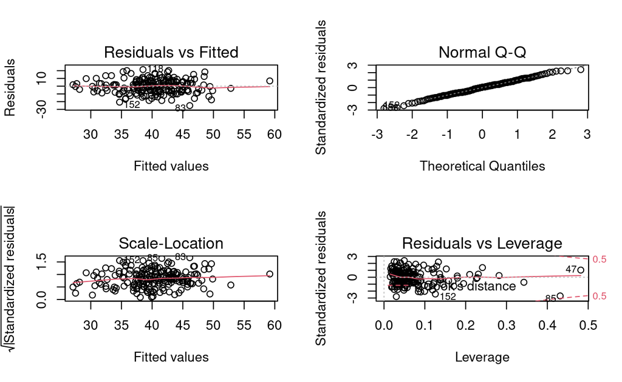

```r
#Modelldiagnostik nicht vergessen
par(mfrow=c(2,2))
plot(global.model)
```

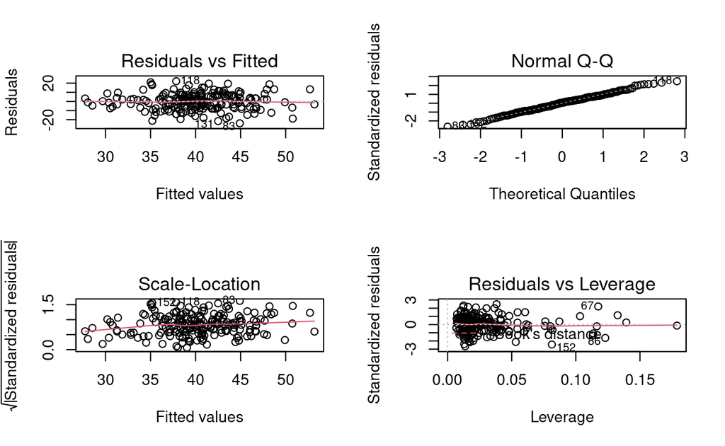

```r
plot(lm(`Species richness`~`Heat index`+Litter+CaCO3+`CN ratio`+ `Grazing intensity`))
```

```r
summary(global.model)
```

```
Call:
lm(formula = `Species richness` ~ Inclination + `Heat index` +
    Microrelief + `Grazing intensity` + Litter + `Stones and rocks` +
    Gravel + `Fine soil` + pH + CaCO3 + `C org` + `CN ratio` +
    Temperature, data = ukraine)

Residuals:
     Min       1Q   Median       3Q      Max
-25.1317  -5.8226   0.5007   5.9982  21.4941

Coefficients:
                     Estimate Std. Error t value Pr(>|t|)
(Intercept)          29.35672   17.93590   1.637  0.10338
Inclination           0.01179    0.08581   0.137  0.89084
`Heat index`        -12.17483    2.41802  -5.035 1.13e-06 ***
Microrelief           0.07488    0.07312   1.024  0.30716
`Grazing intensity`   1.23000    0.67730   1.816  0.07098 .
Litter               -0.12338    0.04309  -2.864  0.00467 **
`Stones and rocks`   -0.14803    0.08840  -1.675  0.09570 .
Gravel               -0.03114    0.12924  -0.241  0.80988
`Fine soil`          -0.08720    0.10181  -0.856  0.39286
pH                   -0.21774    1.70826  -0.127  0.89871
CaCO3                 0.22638    0.10597   2.136  0.03397 *
`C org`               0.31994    0.55929   0.572  0.56798
`CN ratio`           -0.75167    0.33393  -2.251  0.02556 *
Temperature           0.24527    0.21510   1.140  0.25566
---
Signif. codes:  0 '***' 0.001 '**' 0.01 '*' 0.05 '.' 0.1 ' ' 1

Residual standard error: 9.149 on 185 degrees of freedom
Multiple R-squared:  0.2349,    Adjusted R-squared:  0.1812
F-statistic:  4.37 on 13 and 185 DF,  p-value: 2.027e-06
```

Wie immer kommt am Ende die Modelldiagnostik. Wir können uns entweder das globale Modell oder das Modell mit den 5 Variablen mit importance > 50% anschauen. Das Bild sieht fast identisch aus und zeigt keinerlei problematische Abweichungen, d. h. links oben weder ein Keil, noch eine Banane, rechts oben eine nahezu perfekte Gerade.